# Report

uni group

22 August, 2021

```r
library(readr)
library(skimr)
library(janitor)
library(dplyr)
```

```r
library(ggplot2)
library(ggfortify)
library(GGally)
library(qtlcharts)
library(broom)
library(equatiomatic)
library(caret)
library(mplot)

# Setting seed
set.seed(1)
```

# Introduction

Body fat percentage is a popular way to assess an individual’s health. However, accurate measurements are inconvenient and costly.

Questions to answer

- which variables are most important for accurately estimating body fat percentage when we:
  - consider all variables
  - consider only variables that individuals can generate themselves

Note: we want to compare the performance of the following model:

- the model without bodyweight density and the parameters that stay important as the model’s goodness of fit decreases

# Data description

```r
data_orig <- read_tsv("bodyfat.tsv") %>% clean_names
data <- data_orig
```

```r
skim(data_orig)
```

Data summary

| Name | data_orig |
| --- | --- |
| Number of rows | 252 |
| Number of columns | 15 |
| _______________________ |  |
| Column type frequency: |  |
| numeric | 15 |
| ________________________ |  |
| Group variables | None |

**Variable type: numeric**

| skim_variable | n_missing | complete_rate | mean | sd | p0 | p25 | p50 | p75 | p100 | hist |
| --- | --- | --- | --- | --- | --- | --- | --- | --- | --- | --- |
| underwater_density | 0 | 1 | 1.06 | 0.02 | 1.00 | 1.04 | 1.05 | 1.07 | 1.11 | ▁▅▇▆▁ |
| body_fat_siri_equ | 0 | 1 | 19.15 | 8.37 | 0.00 | 12.47 | 19.20 | 25.30 | 47.50 | ▃▇▇▃▁ |
| age | 0 | 1 | 44.88 | 12.60 | 22.00 | 35.75 | 43.00 | 54.00 | 81.00 | ▅▇▇▃▁ |
| height | 0 | 1 | 178.18 | 9.30 | 74.93 | 173.35 | 177.80 | 183.51 | 197.49 | ▁▁▁▂▇ |
| weight_kg | 0 | 1 | 81.16 | 13.33 | 53.75 | 72.12 | 80.06 | 89.36 | 164.72 | ▆▇▂▁▁ |
| neck_circumf | 0 | 1 | 37.99 | 2.43 | 31.10 | 36.40 | 38.00 | 39.42 | 51.20 | ▂▇▃▁▁ |
| chest_circumf | 0 | 1 | 100.82 | 8.43 | 79.30 | 94.35 | 99.65 | 105.38 | 136.20 | ▂▇▅▁▁ |
| abdomen2circumf | 0 | 1 | 92.56 | 10.78 | 69.40 | 84.57 | 90.95 | 99.33 | 148.10 | ▃▇▂▁▁ |
| hip_circumf | 0 | 1 | 99.90 | 7.16 | 85.00 | 95.50 | 99.30 | 103.53 | 147.70 | ▆▇▁▁▁ |
| thigh_circumf | 0 | 1 | 59.41 | 5.25 | 47.20 | 56.00 | 59.00 | 62.35 | 87.30 | ▃▇▃▁▁ |
| knee_circumf | 0 | 1 | 38.59 | 2.41 | 33.00 | 36.98 | 38.50 | 39.92 | 49.10 | ▃▇▅▁▁ |
| ankle_circumf | 0 | 1 | 23.10 | 1.69 | 19.10 | 22.00 | 22.80 | 24.00 | 33.90 | ▃▇▁▁▁ |
| extend_biceps_circumf | 0 | 1 | 32.27 | 3.02 | 24.80 | 30.20 | 32.05 | 34.32 | 45.00 | ▂▇▆▁▁ |
| forearm_circumf | 0 | 1 | 28.66 | 2.02 | 21.00 | 27.30 | 28.70 | 30.00 | 34.90 | ▁▂▇▆▁ |
| wrist_circumf | 0 | 1 | 18.23 | 0.93 | 15.80 | 17.60 | 18.30 | 18.80 | 21.40 | ▂▆▇▂▁ |

The data set consists 15 biometric measurements of 252 different men aged 22 to 81. It was collected in 1985 by the Human Performance Research Center at Brigham Young University in Utah using a central composite rotatable design sampling technique. The measurements recorded include age, height, weight, body density, body fat percentage and 10 circumferences.

# Data cleaning

Before undergoing the model selection process, underwater density should be removed from the dataset due to the following reasons:

1. There is already an existing model for body fat percentage using body density known as Siri’s equation:
   $$PBF = \frac{495}{D} - 450$$
   where $PBF$ is the percentage of body fat and $D$ is body density.
2. Body density obtained using hydrostatic weighing is an impractical process for individuals to undergo and would hinder any attempt at finding a useful model.

```r
data <- data %>% select(-underwater_density)
```

# Data exploration

## Linearity

Before constructing a linear regression model for body fat percentage, we should check that there is a linear relationship between any predictor and body fat percentage.

```r
# Plot all combinations
#ggpairs(data)
iplotCorr(data)
```

```
## Set screen size to height=700 x width=1000
```

[interactive chart not shown]

Viewing the 2nd last row of plots, it is clear that there isn’t a linear relationship between height and body fat percentage as expected, so let’s remove height from the model selection process.

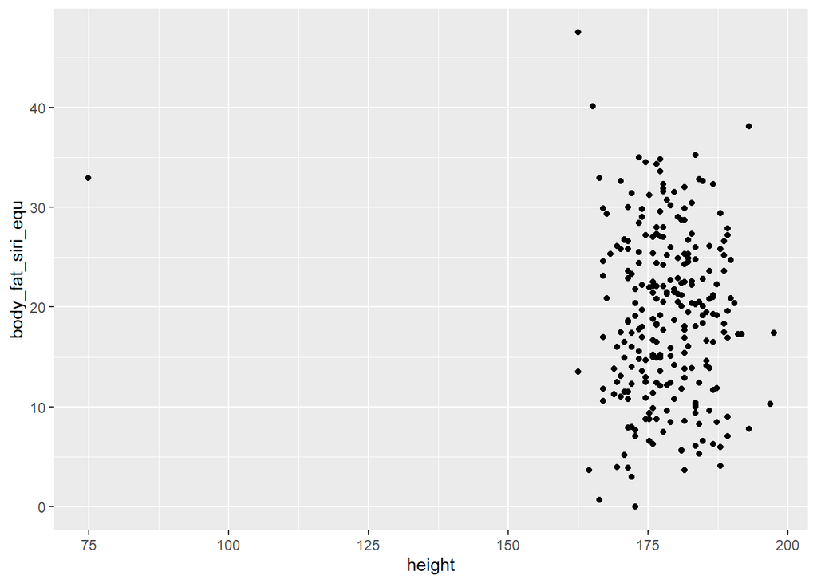

```r
ggplot(data_orig) +
    aes(x=height, y=body_fat_siri_equ) +
    geom_point()
```

```r
# Remove height
data = data %>% select(-height)
```

There are, however, linear relationships for ever remaining possible predictor and the percentage of body fat.

## Independence

All observations in the data set are mutually independent since each entry is the result of measuring a different unique male. This is a consequence of the experimental design.

# Model selection

## Forward-step

```r
# the model with no variables in it
mod0 <- lm(body_fat_siri_equ ~ 1, data)
# the model with all the variables
mod1 <- lm(body_fat_siri_equ ~ ., data)
mod_step_f <- step(mod1, scope = list(lower=mod0, upper=mod1),
                   direction = "forward", trace = FALSE)
summary(mod_step_f)$coef %>% round(3)
```

```
##                       Estimate Std. Error t value Pr(>|t|)
## (Intercept)            -25.574     14.027  -1.823    0.070
## age                      0.065      0.032   2.036    0.043
## weight_kg               -0.234      0.105  -2.226    0.027
## neck_circumf            -0.466      0.232  -2.009    0.046
## chest_circumf           -0.008      0.097  -0.087    0.930
## abdomen2circumf          0.962      0.086  11.203    0.000
## hip_circumf             -0.181      0.141  -1.282    0.201
## thigh_circumf            0.257      0.141   1.823    0.070
## knee_circumf             0.000      0.241   0.001    1.000
## ankle_circumf            0.184      0.221   0.833    0.406
## extend_biceps_circumf    0.188      0.171   1.099    0.273
## forearm_circumf          0.455      0.199   2.288    0.023
## wrist_circumf           -1.659      0.532  -3.120    0.002
```

$$$
\begin{aligned}
\operatorname{\widehat{body\_fat\_siri\_equ}} &= -25.57 + 0.07(\operatorname{age}) - 0.23(\operatorname{weight\_kg}) - 0.47(\operatorname{neck\_circumf})\ - \\
&\quad 0.01(\operatorname{chest\_circumf}) + 0.96(\operatorname{abdomen2circumf}) - 0.18(\operatorname{hip\_circumf}) + 0.26(\operatorname{thigh\_circumf})\ + \\
&\quad 0(\operatorname{knee\_circumf}) + 0.18(\operatorname{ankle\_circumf}) + 0.19(\operatorname{extend\_biceps\_circumf}) + 0.46(\operatorname{forearm\_circumf})\ - \\
&\quad 1.66(\operatorname{wrist\_circumf})
\end{aligned}$$
$

## Backward-step

```r
mod_step_b <- step(mod1, direction = "backward", trace = FALSE)
summary(mod_step_b)$coef %>% round(3)
```

```
##                 Estimate Std. Error t value Pr(>|t|)
## (Intercept)      -22.656     11.714  -1.934    0.054
## age                0.066      0.031   2.137    0.034
## weight_kg         -0.198      0.088  -2.252    0.025
## neck_circumf      -0.467      0.225  -2.077    0.039
## abdomen2circumf    0.945      0.072  13.134    0.000
## hip_circumf       -0.195      0.138  -1.411    0.159
## thigh_circumf      0.302      0.129   2.343    0.020
## forearm_circumf    0.516      0.186   2.768    0.006
## wrist_circumf     -1.537      0.509  -3.017    0.003
```

$$$
\begin{aligned}
\operatorname{\widehat{body\_fat\_siri\_equ}} &= -22.66 + 0.07(\operatorname{age}) - 0.2(\operatorname{weight\_kg}) - 0.47(\operatorname{neck\_circumf})\ + \\
&\quad 0.94(\operatorname{abdomen2circumf}) - 0.2(\operatorname{hip\_circumf}) + 0.3(\operatorname{thigh\_circumf}) + 0.52(\operatorname{forearm\_circumf})\ - \\
&\quad 1.54(\operatorname{wrist\_circumf})
\end{aligned}$$
$

# Assumption checking

## Homoskedasticity

[figure not shown]

```r
# homeskadsticity for forward-step
p1 <-autoplot(mod_step_b, which=1)
p2 <-autoplot(mod_step_f, which=1)
p1 <- p1 + ggtitle("Forward step")
p2 <- p2 + ggtitle("Backward step")
gridExtra::grid.arrange(p1@plots[[1]], p2@plots[[1]], nrow=1)
```